# Bustos_INN_Learner_Notebook_Full_code

```python
%whos
```

[output not shown]

[output cut: 17 more lines]

[output not shown]

```python
# Ensure the best model is used for predictions
y_test_pred = model_3.predict(X_test)  # Replace model_3 with your trained model
y_test_pred = (y_test_pred > 0.5)  # Convert probabilities to binary predictions
print(y_test_pred)
```

```
63/63 ━━━━━━━━━━━━━━━━━━━━ 0s 3ms/step
[[False]
 [ True]
 [False]
 ...
 [ True]
 [False]
 [False]]
```

```python
cr=classification_report(y_test,y_test_pred)
print(cr)
```

```
              precision    recall  f1-score   support

         0.0       0.91      0.70      0.79      1593
         1.0       0.39      0.74      0.51       407

    accuracy                           0.71      2000
   macro avg       0.65      0.72      0.65      2000
weighted avg       0.81      0.71      0.74      2000
```

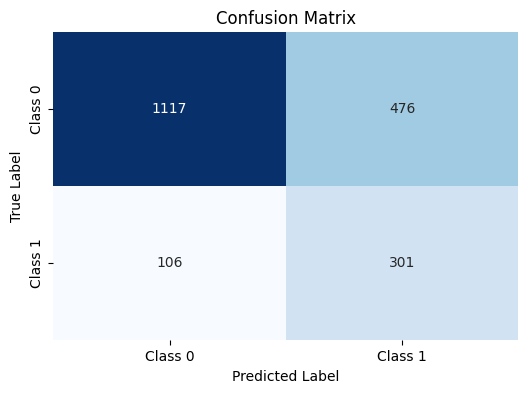

```python
make_confusion_matrix(y_test,y_test_pred)
```

## Actionable Insights and Business Recommendations

# Business Recommendations

### Target Retention Efforts:

Focus retention campaigns on customer segments with a high churn probability as identified by the model. Develop personalized offers or loyalty programs for these customers. Feature-Driven Strategies:

### Age:

If older customers are more likely to churn, offer financial planning or retirement-focused products.

### Balance:

Zero-balance accounts may indicate inactive customers. Provide incentives for account usage.

### Tenure:

New customers may have a higher churn rate. Focus on onboarding experiences and proactive support.

### Enhance Active Membership:

Encourage customers to utilize more bank services or products. Use promotions for credit cards, loans, or savings plans.

### Geographic Strategies:

If specific regions have higher churn, investigate localized challenges (e.g., competition, service issues).

# Actionable Insights

### Data-Driven Marketing:

Use model predictions to identify customers with a high likelihood of churn and implement targeted marketing campaigns.

### Customer Feedback:

Collect feedback from churn-prone segments to understand dissatisfaction and improve services.

### Churn Monitoring:

Establish a churn dashboard to track churn rates, prediction accuracy, and campaign effectiveness.

### Model Refinement:

Periodically retrain the model with updated data to capture changing customer behaviors and market dynamics.